# Concrete_Strength_Prediction_Solution_Sanjay

## Context and Defining Problem Statement

We have data for concrete with various with different values for various independent variables and corresponding concrete strngth (target variables).

Each row in the dataset containts values for how the concrete was made and what is corresponding concrete strength. There are 8 different attributes which contribute making the concrete for corresponding strength.

The objective is to develop linear regression model to predict the concrete strength using the data available and apply feature engineering and model tuning to obtain 80% to 95% of R2score.

The data for this project is available in file https://archive.ics.uci.edu/ml/machine-learning-databases/concrete/compressive/.

## Import analytics packages and data

```python
import numpy as np
import pandas as pd

import matplotlib.pyplot as plt
%matplotlib inline
import seaborn as sns
sns.set(color_codes=True)  # adds a nice background to the graphs

import warnings
warnings.filterwarnings('ignore')

# Remove scientific notations and display numbers with 2 decimal points instead
pd.options.display.float_format = '{:,.2f}'.format
```

```python
data = pd.read_csv('concrete.csv')
```

```python
data.head()
```

|  | cement | slag | ash | water | superplastic | coarseagg | fineagg | age | strength |
| --- | --- | --- | --- | --- | --- | --- | --- | --- | --- |
| 0 | 141.3 | 212.0 | 0.0 | 203.5 | 0.0 | 971.8 | 748.5 | 28 | 29.89 |
| 1 | 168.9 | 42.2 | 124.3 | 158.3 | 10.8 | 1080.8 | 796.2 | 14 | 23.51 |
| 2 | 250.0 | 0.0 | 95.7 | 187.4 | 5.5 | 956.9 | 861.2 | 28 | 29.22 |
| 3 | 266.0 | 114.0 | 0.0 | 228.0 | 0.0 | 932.0 | 670.0 | 28 | 45.85 |
| 4 | 154.8 | 183.4 | 0.0 | 193.3 | 9.1 | 1047.4 | 696.7 | 28 | 18.29 |

## Perform Univariate Analysis

Explore data types and description of the independent attributes which should include (name, range of values observed, central values (mean and median), standard deviation and quartiles, analysis of the body of distributions / tails, missing values, outliers, duplicates

### Check data type

```python
data.dtypes
```

```
cement          float64
slag            float64
ash             float64
water           float64
superplastic    float64
coarseagg       float64
fineagg         float64
age               int64
strength        float64
dtype: object
```

### Check how many unique value are available for each feature, if any. It will help us understand if there are any categorical features

```python
data.nunique()
```

```
cement          278
slag            185
ash             156
water           195
superplastic    111
coarseagg       284
fineagg         302
age              14
strength        845
dtype: int64
```

### Check if any column has any null value

```python
data.isna().sum()
```

```
cement          0
slag            0
ash             0
water           0
superplastic    0
coarseagg       0
fineagg         0
age             0
strength        0
dtype: int64
```

There are no null value in any column

### Check basic information about the dataset to understand null values, shape of the data, number of features, number of observations etc.

```python
data.info()
```

```
<class 'pandas.core.frame.DataFrame'>
RangeIndex: 1030 entries, 0 to 1029
Data columns (total 9 columns):
cement          1030 non-null float64
slag            1030 non-null float64
ash             1030 non-null float64
water           1030 non-null float64
superplastic    1030 non-null float64
coarseagg       1030 non-null float64
fineagg         1030 non-null float64
age             1030 non-null int64
strength        1030 non-null float64
dtypes: float64(8), int64(1)
memory usage: 72.5 KB
```

There are total 9 columns and 1030 records available. As noted eariler, none of the column has any null value

### Print the descriptive statistics of each & every column as requested in the problem

```python
data.describe()
```

|  | cement | slag | ash | water | superplastic | coarseagg | fineagg | age | strength |
| --- | --- | --- | --- | --- | --- | --- | --- | --- | --- |
| count | 1030.000000 | 1030.000000 | 1030.000000 | 1030.000000 | 1030.000000 | 1030.000000 | 1030.000000 | 1030.000000 | 1030.000000 |
| mean | 281.167864 | 73.895825 | 54.188350 | 181.567282 | 6.204660 | 972.918932 | 773.580485 | 45.662136 | 35.817961 |
| std | 104.506364 | 86.279342 | 63.997004 | 21.354219 | 5.973841 | 77.753954 | 80.175980 | 63.169912 | 16.705742 |
| min | 102.000000 | 0.000000 | 0.000000 | 121.800000 | 0.000000 | 801.000000 | 594.000000 | 1.000000 | 2.330000 |
| 25% | 192.375000 | 0.000000 | 0.000000 | 164.900000 | 0.000000 | 932.000000 | 730.950000 | 7.000000 | 23.710000 |
| 50% | 272.900000 | 22.000000 | 0.000000 | 185.000000 | 6.400000 | 968.000000 | 779.500000 | 28.000000 | 34.445000 |
| 75% | 350.000000 | 142.950000 | 118.300000 | 192.000000 | 10.200000 | 1029.400000 | 824.000000 | 56.000000 | 46.135000 |
| max | 540.000000 | 359.400000 | 200.100000 | 247.000000 | 32.200000 | 1145.000000 | 992.600000 | 365.000000 | 82.600000 |

We can understand whether data is right skewed or left skewed by using following defination:

- Mean > Median : Positive or right skewed distribution
- Mean = Median: Zero skewness or symmetrical distribution
- Mean < Median : Negative or left skewed distribution

The descriptive statistics provide mean and median (50%) to understand the skeweness in the data

### Generate bar charts for various features to see the data distribution

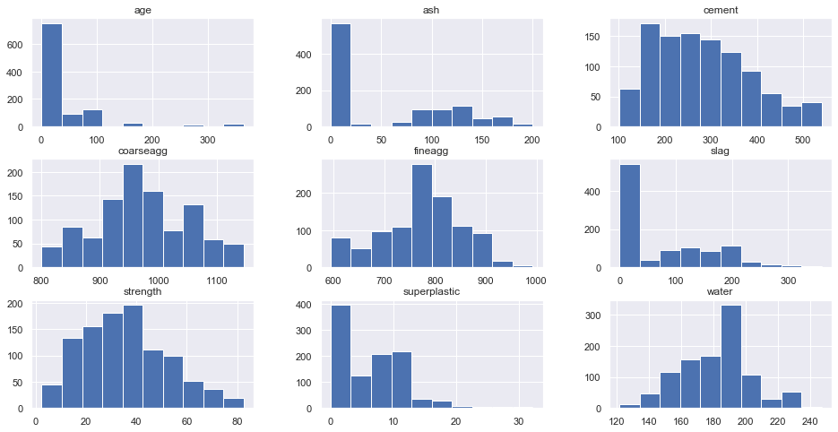

```python
data.hist(figsize=(16,8));
```

```python
data.skew()
```

```
cement          0.509481
slag            0.800717
ash             0.537354
water           0.074628
superplastic    0.907203
coarseagg      -0.040220
fineagg        -0.253010
age             3.269177
strength        0.416977
dtype: float64
```

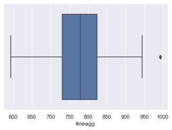

```python
sns.boxplot(data['fineagg']);
```

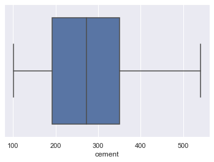

```python
sns.boxplot(data['cement']);
```

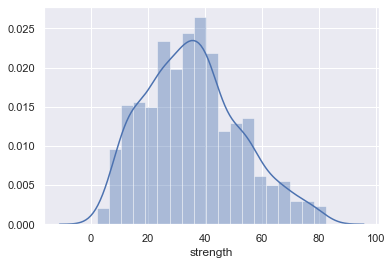

```python
sns.distplot(data['strength']);
```

Above charts including bar charts, shows that most of the features are right skewed however 'coarseagg' follows quite normal distribution and 'fineagg' is also close to normal distribution

### Perform Bi-variate analysis

#### Generate pair plot to see the relationship between independent variables and between independent and target variable

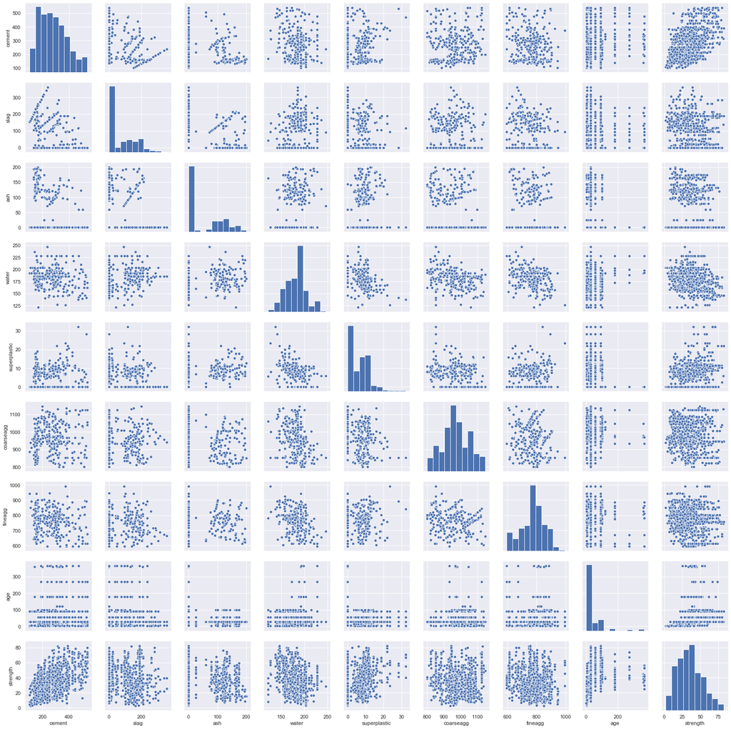

```python
sns.pairplot(data);
```

The pair plot doesn't show a clear relationship between variables except for strength and cemeent. Strength and cemenet shows positive degree of relationship.

### Calculate correlation for feature selection

We can use correlation for feature selection. In case if any two features have 0.9 or more correlation then we can drop one of the feature from there.

```python
data.corr()
```

|  | cement | slag | ash | water | superplastic | coarseagg | fineagg | age | strength |
| --- | --- | --- | --- | --- | --- | --- | --- | --- | --- |
| cement | 1.000000 | -0.275216 | -0.397467 | -0.081587 | 0.092386 | -0.109349 | -0.222718 | 0.081946 | 0.497832 |
| slag | -0.275216 | 1.000000 | -0.323580 | 0.107252 | 0.043270 | -0.283999 | -0.281603 | -0.044246 | 0.134829 |
| ash | -0.397467 | -0.323580 | 1.000000 | -0.256984 | 0.377503 | -0.009961 | 0.079108 | -0.154371 | -0.105755 |
| water | -0.081587 | 0.107252 | -0.256984 | 1.000000 | -0.657533 | -0.182294 | -0.450661 | 0.277618 | -0.289633 |
| superplastic | 0.092386 | 0.043270 | 0.377503 | -0.657533 | 1.000000 | -0.265999 | 0.222691 | -0.192700 | 0.366079 |
| coarseagg | -0.109349 | -0.283999 | -0.009961 | -0.182294 | -0.265999 | 1.000000 | -0.178481 | -0.003016 | -0.164935 |
| fineagg | -0.222718 | -0.281603 | 0.079108 | -0.450661 | 0.222691 | -0.178481 | 1.000000 | -0.156095 | -0.167241 |
| age | 0.081946 | -0.044246 | -0.154371 | 0.277618 | -0.192700 | -0.003016 | -0.156095 | 1.000000 | 0.328873 |
| strength | 0.497832 | 0.134829 | -0.105755 | -0.289633 | 0.366079 | -0.164935 | -0.167241 | 0.328873 | 1.000000 |

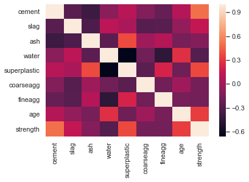

```python
sns.heatmap(data.corr());
```

We can visualize that there are no strong correlation between any two variables however we can see some correlation:

Correlation between independent variables: ash and superplastic, age and water  
Correlation between independent variable and target variable:strength and cement, superplastic and strength, age and strength

- We will not be able to drop any feature based on correlation since none of the two parameters have strong correlation

### Prepare the data for analytics - Perform preprocessing activities

#### The data in different columns have large variance in scale hence lets scale the data. In this method we convert variable with different scales of measurement into a single scale.

```python
from sklearn.preprocessing import StandardScaler
```

```python
data.head()
```

|  | cement | slag | ash | water | superplastic | coarseagg | fineagg | age | strength |
| --- | --- | --- | --- | --- | --- | --- | --- | --- | --- |
| 0 | 141.3 | 212.0 | 0.0 | 203.5 | 0.0 | 971.8 | 748.5 | 28 | 29.89 |
| 1 | 168.9 | 42.2 | 124.3 | 158.3 | 10.8 | 1080.8 | 796.2 | 14 | 23.51 |
| 2 | 250.0 | 0.0 | 95.7 | 187.4 | 5.5 | 956.9 | 861.2 | 28 | 29.22 |
| 3 | 266.0 | 114.0 | 0.0 | 228.0 | 0.0 | 932.0 | 670.0 | 28 | 45.85 |
| 4 | 154.8 | 183.4 | 0.0 | 193.3 | 9.1 | 1047.4 | 696.7 | 28 | 18.29 |

Let's scale all columns except age and target variable('strength')

```python
cols_to_scale = ['cement','slag','ash','water', 'superplastic', 'coarseagg', 'fineagg']
std_scale = StandardScaler()
data[cols_to_scale] = std_scale.fit_transform(data[cols_to_scale])
```

```python
data.head()
```

|  | cement | slag | ash | water | superplastic | coarseagg | fineagg | age | strength |
| --- | --- | --- | --- | --- | --- | --- | --- | --- | --- |
| 0 | -1.339017 | 1.601441 | -0.847144 | 1.027590 | -1.039143 | -0.014398 | -0.312970 | 28 | 29.89 |
| 1 | -1.074790 | -0.367541 | 1.096078 | -1.090116 | 0.769617 | 1.388141 | 0.282260 | 14 | 23.51 |
| 2 | -0.298384 | -0.856888 | 0.648965 | 0.273274 | -0.118015 | -0.206121 | 1.093371 | 28 | 29.22 |
| 3 | -0.145209 | 0.465044 | -0.847144 | 2.175461 | -1.039143 | -0.526517 | -1.292542 | 28 | 45.85 |
| 4 | -1.209776 | 1.269798 | -0.847144 | 0.549700 | 0.484905 | 0.958372 | -0.959363 | 28 | 18.29 |

### Import Linear Regression machine learning libraries

```python
# Import Linear Regression machine learning library
from sklearn.linear_model import LinearRegression

# for linear regression with regulrization
from sklearn.linear_model import Ridge
from sklearn.linear_model import Lasso

# create train test data split
from sklearn.model_selection import train_test_split

# for polynomial regression
from sklearn.preprocessing import PolynomialFeatures


from sklearn.metrics import mean_squared_error, r2_score, mean_absolute_error, max_error
```

```python
features = data.drop('strength', axis=1)
label = data['strength']

x_train, x_test, y_train, y_test = train_test_split(features, label, test_size=0.30, random_state=3)
x_train.shape
```

```
(721, 8)
```

### Using p-value for feature selection

```python
# use OLS algorithm. provides pvalues and summary
import statsmodels.api as sm

X2 = sm.add_constant(features) # sm.OLS by default does not add an intercept in the model.so we manually added it
y2 = label

lm= sm.OLS(y2,X2).fit()  #A simple ordinary least squares model.

print("p-values for each column:")
print(lm.pvalues)

lm.summary()
```

```
p-values for each column:
const          0.00
cement         0.00
slag           0.00
ash            0.00
water          0.00
superplastic   0.00
coarseagg      0.05
fineagg        0.06
age            0.00
dtype: float64
```

OLS Regression Results

| Dep. Variable: | strength | R-squared: | 0.616 |
| --- | --- | --- | --- |
| Model: | OLS | Adj. R-squared: | 0.613 |
| Method: | Least Squares | F-statistic: | 204.3 |
| Date: | Fri, 28 Aug 2020 | Prob (F-statistic): | 6.29e-206 |
| Time: | 09:03:39 | Log-Likelihood: | -3869.0 |
| No. Observations: | 1030 | AIC: | 7756. |
| Df Residuals: | 1021 | BIC: | 7800. |
| Df Model: | 8 |  |  |
| Covariance Type: | nonrobust |  |  |

|  | coef | std err | t | P>\|t\| | [0.025 | 0.975] |
| --- | --- | --- | --- | --- | --- | --- |
| const | 30.6023 | 0.408 | 75.019 | 0.000 | 29.802 | 31.403 |
| cement | 12.5142 | 0.887 | 14.113 | 0.000 | 10.774 | 14.254 |
| slag | 8.9571 | 0.874 | 10.247 | 0.000 | 7.242 | 10.672 |
| ash | 5.6248 | 0.805 | 6.988 | 0.000 | 4.045 | 7.204 |
| water | -3.1998 | 0.858 | -3.731 | 0.000 | -4.883 | -1.517 |
| superplastic | 1.7449 | 0.558 | 3.128 | 0.002 | 0.650 | 2.839 |
| coarseagg | 1.4056 | 0.730 | 1.926 | 0.054 | -0.027 | 2.838 |
| fineagg | 1.6180 | 0.858 | 1.887 | 0.059 | -0.065 | 3.301 |
| age | 0.1142 | 0.005 | 21.046 | 0.000 | 0.104 | 0.125 |

| Omnibus: | 5.378 | Durbin-Watson: | 1.870 |
| --- | --- | --- | --- |
| Prob(Omnibus): | 0.068 | Jarque-Bera (JB): | 5.304 |
| Skew: | -0.174 | Prob(JB): | 0.0705 |
| Kurtosis: | 3.045 | Cond. No. | 450. |

Warnings:  
[1] Standard Errors assume that the covariance matrix of the errors is correctly specified.

#### Create a helper function to store metrics values in a dataframe for each model for comparison

```python
modelMatrix = pd.DataFrame(columns = ['Method', 'R2 Score', 'MAE', 'MSE', 'RMSE', 'Max Error'])
def prepDF(modelName,y_test,y_pred):
    new_df = pd.DataFrame({'Method': [modelName],
                        'R2 Score': [r2_score(y_test, y_pred)],
                        'MAE': [mean_absolute_error(y_test, y_pred)],
                        'MSE': [mean_squared_error(y_test, y_pred)],
                        'RMSE': [mean_squared_error(y_test, y_pred)**0.5],
                        'Max Error': [max_error(y_test, y_pred)] })
    return new_df
```

```python
lr = LinearRegression()
model = lr.fit(x_train, y_train)
print('Intercept: ', model.intercept_)
print()
print('Cofficients: ',model.coef_)
```

```
Intercept:  30.118629039515678

Cofficients:  [11.74925457  8.19009823  5.28243943 -3.65237172  1.52485524  0.93139044
  0.7549118   0.11959145]
```

```python
# make prediction
y_pred = model.predict(x_test)
#y_pred
```

### Metrics to evaluate model performance

```python
# Check model accuracy. use.score function to Calculate the accuracy of the model for both training and test data set
print('Score value for in-sample: ',model.score(x_train, y_train))
print('Score value for out-of-sample: ',model.score(x_test, y_test))

lrDF = prepDF('Simple Linear Regression', y_test, y_pred)
lrDF

# print("R2 score (coefficient of determination): ", r2_score(y_test, y_pred))
# print()

# print("Mean Absolute Error (MAE): ", mean_absolute_error(y_test, y_pred))
# print("Mean Square Error (MSE): ", mean_squared_error(y_test, y_pred))
# print("Root Mean Square Error (RMSE): ", mean_squared_error(y_test, y_pred)**0.5)
# print("Max Error: ", max_error(y_test, y_pred))
# print()
```

```
Score value for in-sample:  0.6079139462867476
Score value for out-of-sample:  0.6266471974385557
```

|  | Method | R2 Score | MAE | MSE | RMSE | Max Error |
| --- | --- | --- | --- | --- | --- | --- |
| 0 | Simple Linear Regression | 0.626647 | 8.091056 | 108.189807 | 10.401433 | 35.166319 |

- The model doesn't seem to be underfit or overfit however it being a simple model, accuracy is not that good. R square value is also not good.
- We need to generate polynomial degree of attributes to increase the complexity of the model to get better accuracy

### Create Linear Regression model using Ploynomial terms - Perform Feature Engineering by adding more features

Following model uses interaction only terms e.g. X1xX2, X2xX3 etc. It is not use higher degree of independet variables (e.g X square etc.)

```python
poly = PolynomialFeatures(degree=2, interaction_only=True)
poly
```

```
PolynomialFeatures(degree=2, include_bias=True, interaction_only=True,
                   order='C')
```

```python
x_train2 = poly.fit_transform(x_train)
x_test2 = poly.fit_transform(x_test)
x_train2.shape
```

```
(721, 37)
```

- We can note that by including polynomial terms, number of features have increased from 8 to 37
- It has increased the model complexity but it is expected to increase the model accuracy as well

```python
plr = LinearRegression()
pmodel = plr.fit(x_train2, y_train)
y_pred1 = pmodel.predict(x_test2)
```

### Metrics to evaluate model performance

```python
# Check model accuracy. use.score function to Calculate the accuracy of the model for both training and test data set
print('Score value for in-sample: ',pmodel.score(x_train2, y_train))
print('Score value for out-of-sample: ',pmodel.score(x_test2, y_test))

prDF = prepDF('Polynomial Regression', y_test, y_pred1)
prDF

# print("R Square (coefficient of determination): ", r2_score(y_test, y_pred1))
# print()

# print("Mean Absolute Error (MAE): ", mean_absolute_error(y_test, y_pred1))
# print("Mean Square Error (MSE): ", mean_squared_error(y_test, y_pred1))
# print("Root Mean Square Error (RMSE): ", mean_squared_error(y_test, y_pred1)**0.5)
# print("Max Error: ", max_error(y_test, y_pred1))
# print()
```

```
Score value for in-sample:  0.7531500832088669
Score value for out-of-sample:  0.7453824673797453
```

|  | Method | R2 Score | MAE | MSE | RMSE | Max Error |
| --- | --- | --- | --- | --- | --- | --- |
| 0 | Polynomial Regression | 0.745382 | 6.800639 | 73.782817 | 8.589692 | 31.921193 |

###### Let's compare linear regression and polynomial regression

```python
pd.concat([lrDF,prDF])
```

|  | Method | R2 Score | MAE | MSE | RMSE | Max Error |
| --- | --- | --- | --- | --- | --- | --- |
| 0 | Simple Linear Regression | 0.626647 | 8.091056 | 108.189807 | 10.401433 | 35.166319 |
| 0 | Polynomial Regression | 0.745382 | 6.800639 | 73.782817 | 8.589692 | 31.921193 |

We can note that R2 score and other metrics value has improved in case of Polynomial Regression

### Implement Ridge regularization to improve model performance

```python
rlr = Ridge(alpha=.3)
rmodel = rlr.fit(x_train2, y_train)
y_pred3 = rmodel.predict(x_test2)
print('Score value for in-sample: ',rmodel.score(x_train2, y_train))
print('Score value for out-of-sample: ',rmodel.score(x_test2, y_test))

rlrDF = prepDF('Regularized Ridge  Model', y_test, y_pred3)
rlrDF
```

```
Score value for in-sample:  0.7531476758978023
Score value for out-of-sample:  0.7452540966410637
```

|  | Method | R2 Score | MAE | MSE | RMSE | Max Error |
| --- | --- | --- | --- | --- | --- | --- |
| 0 | Regularized Ridge Model | 0.745254 | 6.801028 | 73.820016 | 8.591858 | 31.896361 |

### Implement Lasso regularization to improve model performance

```python
llr = Lasso(alpha=.1)
lmodel = llr.fit(x_train2, y_train)
y_pred4 = lmodel.predict(x_test2)
print('Score value for in-sample: ',lmodel.score(x_train2, y_train))
print('Score value for out-of-sample: ',lmodel.score(x_test2, y_test))

llrDF = prepDF('Regularized Lasso  Model', y_test, y_pred4)
llrDF
```

```
Score value for in-sample:  0.748161598092437
Score value for out-of-sample:  0.7430586303260021
```

|  | Method | R2 Score | MAE | MSE | RMSE | Max Error |
| --- | --- | --- | --- | --- | --- | --- |
| 0 | Regularized Lasso Model | 0.74 | 6.76 | 74.46 | 8.63 | 33.65 |

### Let's compare all models generated so far

```python
pd.concat([lrDF,prDF,rlrDF,llrDF])
```

|  | Method | R2 Score | MAE | MSE | RMSE | Max Error |
| --- | --- | --- | --- | --- | --- | --- |
| 0 | Simple Linear Regression | 0.626647 | 8.091056 | 108.189807 | 10.401433 | 35.166319 |
| 0 | Polynomial Regression | 0.745382 | 6.800639 | 73.782817 | 8.589692 | 31.921193 |
| 0 | Regularized Ridge Model | 0.745254 | 6.801028 | 73.820016 | 8.591858 | 31.896361 |
| 0 | Regularized Lasso Model | 0.743059 | 6.760198 | 74.456216 | 8.628802 | 33.649157 |

### Implement additional machine learning mdoels

#### Implement Decision Tree Algorithm

```python
from sklearn.tree import DecisionTreeRegressor
#from sklearn.ensemble import RandomForestClassifier, BaggingClassifier, AdaBoostClassifier
```

```python
dtr = DecisionTreeRegressor(random_state=0)
dmodel = dtr.fit(x_train2, y_train)
y_pred5 = dmodel.predict(x_test2)
print('Score value for in-sample: ',dmodel.score(x_train2, y_train))
print('Score value for out-of-sample: ',dmodel.score(x_test2, y_test))

dtrDF = prepDF('Decision Tree  Model', y_test, y_pred5)
dtrDF
```

```
Score value for in-sample:  0.9958506117361253
Score value for out-of-sample:  0.8153777997089732
```

|  | Method | R2 Score | MAE | MSE | RMSE | Max Error |
| --- | --- | --- | --- | --- | --- | --- |
| 0 | Decision Tree Model | 0.82 | 4.88 | 53.50 | 7.31 | 48.02 |

#### Implement RandomForest Algorithm

```python
from sklearn.ensemble import RandomForestRegressor
```

```python
rfr = RandomForestRegressor(max_depth=9, random_state=0)
rfmodel = rfr.fit(x_train2, y_train)
y_pred6 = rfmodel.predict(x_test2)
print('Score value for in-sample: ',rfmodel.score(x_train2, y_train))
print('Score value for out-of-sample: ',rfmodel.score(x_test2, y_test))

rfrDF = prepDF('Random Forest  Model', y_test, y_pred6)
rfrDF
```

```
Score value for in-sample:  0.9679961536891868
Score value for out-of-sample:  0.8670314933253344
```

|  | Method | R2 Score | MAE | MSE | RMSE | Max Error |
| --- | --- | --- | --- | --- | --- | --- |
| 0 | Random Forest Model | 0.87 | 4.30 | 38.53 | 6.21 | 34.50 |

#### Implement Bagging Regressor

```python
from sklearn.ensemble import BaggingRegressor
```

```python
br = BaggingRegressor(base_estimator=dtr, n_estimators=15, random_state=0)
brmodel = br.fit(x_train2, y_train)
y_pred7 = brmodel.predict(x_test2)
print('Score value for in-sample: ',brmodel.score(x_train2, y_train))
print('Score value for out-of-sample: ',brmodel.score(x_test2, y_test))

brDF = prepDF('Bagging Regressor  Model', y_test, y_pred7)
brDF
```

```
Score value for in-sample:  0.9800965038077325
Score value for out-of-sample:  0.888567128970926
```

|  | Method | R2 Score | MAE | MSE | RMSE | Max Error |
| --- | --- | --- | --- | --- | --- | --- |
| 0 | Bagging Regressor Model | 0.89 | 3.92 | 32.29 | 5.68 | 28.95 |

#### Implement AdaBoost Regressor

```python
from sklearn.ensemble import AdaBoostRegressor
```

```python
abr = AdaBoostRegressor(n_estimators=20, random_state=5) # By default base_estimator - DecisionTreeClassifier
abmodel = abr.fit(x_train2, y_train)
y_pred8 = abmodel.predict(x_test2)
print('Score value for in-sample: ',abmodel.score(x_train2, y_train))
print('Score value for out-of-sample: ',abmodel.score(x_test2, y_test))

abDF = prepDF('AdaBoost Regressor  Model', y_test, y_pred8)
abDF
```

```
Score value for in-sample:  0.8184513513941
Score value for out-of-sample:  0.7496508352867863
```

|  | Method | R2 Score | MAE | MSE | RMSE | Max Error |
| --- | --- | --- | --- | --- | --- | --- |
| 0 | AdaBoost Regressor Model | 0.75 | 6.90 | 72.55 | 8.52 | 28.72 |

### Calculate Cross Validation Score

```python
from sklearn.model_selection import cross_val_score
```

```python
#For Decision Tree
cv_score = cross_val_score(dmodel, x_train2, y_train, cv = 10).mean()
print('Cross validation score of Decision tree = ',cv_score)
```

```
Cross validation score of Decision tree =  0.78127283831196
```

```python
#For RandomForest
cv_score = cross_val_score(rfmodel, x_train2, y_train, cv = 10).mean()
print('Cross validation score of Random Forest = ',cv_score)
```

```
Cross validation score of Random Forest =  0.8735812926524181
```

### Perform hyperparameters tuning to get best model for the given dataset

```python
# For Hyperparameter tunings
from sklearn.model_selection import GridSearchCV
from sklearn.model_selection import RandomizedSearchCV
# We need to pass the model object not the trained model in GridSearchCV function
```

#### Using GridSearchCV

```python
# Hyperparameter grid for Decision Tree
grid_param = {'criterion':['mse','friedman_mse','mae'],'min_samples_leaf':[1, 5, 10, 20, 50, 100], 'max_depth':[4,5,6,7,8,9,10,11,12,15,20,30,40,50,70,90,120,150]}
dtrgs = GridSearchCV(DecisionTreeRegressor(), grid_param, cv=5)
dtrgs.fit(x_train2, y_train)
```

[output not shown]

```python
y_pred_g = dtrgs.predict(x_test2)

print('Score value for in-sample: ',dtrgs.score(x_train2, y_train))
print('Score value for out-of-sample: ',dtrgs.score(x_test2, y_test))

print()
print('Best Parameter: ',dtrgs.best_params_ )
gsDF = prepDF('Decision Tree with GridSearchCV', y_test, y_pred_g)
gsDF
```

[output not shown]

|  | Method | R2 Score | MAE | MSE | RMSE | Max Error |
| --- | --- | --- | --- | --- | --- | --- |
| 0 | Decision Tree with GridSearchCV | 0.74 | 5.30 | 75.60 | 8.69 | 58.91 |

#### Using RandomizedSearchCV

```python
rand_dt = RandomizedSearchCV(estimator=DecisionTreeRegressor(), param_distributions = grid_param, n_iter = 100, cv = 3, verbose=2, random_state=42, n_jobs=-1) # Fit the random search model
best_model_rand = rand_dt.fit(x_train2, y_train)
```

[output not shown]

[output not shown]

```python
y_pred_r = best_model_rand.predict(x_test2)

print('Score value for in-sample: ',best_model_rand.score(x_train2, y_train))
print('Score value for out-of-sample: ',best_model_rand.score(x_test2, y_test))

print()
print('Best Parameter: ',best_model_rand.best_params_ )
rsDF = prepDF('Decision Tree with RSCV', y_test, y_pred_r)
rsDF
```

[output not shown]

|  | Method | R2 Score | MAE | MSE | RMSE | Max Error |
| --- | --- | --- | --- | --- | --- | --- |
| 0 | Decision Tree with RSCV | 0.81 | 4.98 | 55.28 | 7.44 | 43.05 |

### Let's combine results from each model and compare

```python
pd.concat([lrDF,prDF,rlrDF,llrDF,dtrDF,rfrDF,brDF,abDF,gsDF,rsDF])
```

|  | Method | R2 Score | MAE | MSE | RMSE | Max Error |
| --- | --- | --- | --- | --- | --- | --- |
| 0 | Simple Linear Regression | 0.63 | 8.09 | 108.19 | 10.40 | 35.17 |
| 0 | Polynomial Regression | 0.75 | 6.80 | 73.78 | 8.59 | 31.92 |
| 0 | Regularized Ridge Model | 0.75 | 6.80 | 73.82 | 8.59 | 31.90 |
| 0 | Regularized Lasso Model | 0.74 | 6.76 | 74.46 | 8.63 | 33.65 |
| 0 | Decision Tree Model | 0.82 | 4.88 | 53.50 | 7.31 | 48.02 |
| 0 | Random Forest Model | 0.87 | 4.30 | 38.53 | 6.21 | 34.50 |
| 0 | Bagging Regressor Model | 0.89 | 3.92 | 32.29 | 5.68 | 28.95 |
| 0 | AdaBoost Regressor Model | 0.75 | 6.90 | 72.55 | 8.52 | 28.72 |
| 0 | Decision Tree with GridSearchCV | 0.74 | 5.30 | 75.60 | 8.69 | 58.91 |
| 0 | Decision Tree with RSCV | 0.81 | 4.98 | 55.28 | 7.44 | 43.05 |

We can make following observations based on various models and their accuracies:

- We can note that simple linear regression model returned very low result. It was being very simple and was not able to capture the enough variance hence low accuracy.
- Once we implemented feature engineering using polynomial terms then we can see the improvement in the resultant model accuracy.
- Once we implemented regularization using Ridge and Lasso then we can see that both returned almost similar result but there was not much improvement in the accuracy.
- More advance models like Decision Tree and other ensemble model helped achieving better accuracy. Bagging Regressor was able to deliver the best accuracy among all generted models.
- Implmented GridSearchCV and RandomizedSearhCV however couldn't get much improvement using the techniques.